# An introduction to EM algorithm for Gaussian mixture of two models in 1D

Tran Le

2/12/2022

# 1 Introduction

This is the note that I use for learning about EM algorithm. Others sections (EM introduction, R codes, Em for mixtures of $k>=2$ Gaussian distribution in 1D and 2D) could be found from [here](https://tranktle.github.io/portfolio/2022/03/31/EM-Mixture-Gaussian.html).

# 2 Two components Normal mixtures with unknown parameters

We first consider the case of two mixing Normal distributions with unknown parameters in $d=1$ dimension.

Let’s $Y_i, i=\overline{1,n}$ are observed data gotten from a mixture of two Normal distributions with unknown parameters in 1 dimension space. We also don’t know about the distribution to which each data point belongs. The distribution of $Y$ can be written at the weighted sum of two other distributions.

$$\begin{align}
f(y) &= p_1 f_1(y|\mu_1, \sigma_1^2)+p_2 f_2(y|\mu_2, \sigma_2^2), \text{ where } p_1+p_2=1\\
&= p f_1(y) + (1-p) f_2(y)\\
&\quad f_1 \equiv N(\mu_1, \sigma_1^2), \text{ where } \mu_1, \sigma_1^2 \text{ are unknown }\\
&\quad f_2 \equiv N(\mu_2, \sigma_1^2), \text{ where } \mu_2, \sigma_2^2 \text{ are unknown }
\end{align}$$

We want to use EM algorithm to estimate $\boldsymbol{\theta}= (p, \mu_1, \sigma_1^2, \mu_2, \sigma_2^2)$

Let $U_i \sim Bernoulli(p)$, is the distribution label of the data point $i$. When $U_1 =1$, $y_i$ comes from population 1, and when $U_i=0$, $y_i$ comes from population 2 . We will use EM algorithm to solve this problem.

## 2.1 E step

We want to compute the $Q$ function

$$\begin{align}
Q(\boldsymbol{\theta}|\boldsymbol{\theta}^{(s)} ) &= Q(p, \mu_1, \sigma_1^2, \mu_2, \sigma_2^2| p^{(s)}, \mu_1^{(s)}, \sigma_1^{2(s)}, \mu_2^{(s)}, \sigma_2^{2(s)})\\
&= E_{Y_{miss}}\left[ln\left(f(Y_{obs}, Y_{miss}|\boldsymbol{\theta})\right) | Y_{obs}, \boldsymbol{\theta}^{(s)} \right]\\
&= E_{U}\left[ln\left(f(\boldsymbol{Y},\boldsymbol{U})|\boldsymbol{\theta})\right) | Y, \boldsymbol{\theta}^{(s)} \right]\tag{2.1}
\end{align}$$

- The complete data likelihood

$$\begin{align}
f(\boldsymbol{Y},\boldsymbol{U}|\boldsymbol{\theta})&= \prod_{i=1}^n f(y_i) = \prod_{i=1}^n (pf_1(y_i))^{u_i} ((1-p)f_2(y_i))^{(1-u_i)}
\end{align}$$

- The complete data log-likelihood:

$$\begin{align}
ln(f(\boldsymbol{Y},\boldsymbol{U}|\boldsymbol{\theta}))&= \sum_{i=1}^n \left[u_i ln(pf_1(y_i) + (1-u_i) ln((1-p)f_2(y_i))\right]\tag{2.2}
\end{align}$$

- We will also need to find $E(\boldsymbol{U}|\boldsymbol{Y}, \boldsymbol{\theta}^{(s)})$. We now want to find the distribution of $U_i$. We have

$$\begin{align*}
P(U_i =1 | p, Y_i=y_i) &\propto P(U_i=1| Y_i=y_i, p)\\
&= P(U_i=1| p) P(Y_i=y_i| U_i=1, p)\\
&= p f_1(y_i)
\end{align*}$$
So we have

$$P(U_i=1| p, Y_i=y_i) = \frac{p f_1(y_i)}{p f_1(y_i) + (1-p) f_2(y_i)}$$
which means

$$\begin{equation}
U_i |_{p, Y_i=y_i} \sim Bernoulli\left(\frac{p f_1(y_i)}{p f_1(y_i) + (1-p) f_2(y_i)}\right)
\tag{2.3}
\end{equation}$$

- Now, we have enough elements to compute the $Q$ function, use (2.1) and (2.2), we have

$$\begin{align*}
Q(\boldsymbol{\theta}|\boldsymbol{\theta}^{(s)}) &= E_{U}\left[ln\left(f(\boldsymbol{Y},\boldsymbol{U})|\boldsymbol{\theta})\right) | \boldsymbol{Y}, \boldsymbol{\theta}^{(s)} \right]\\
&= E_U\left[\sum_{i=1}^n \left[u_i ln(pf_1(y_i)) + (1-u_i) ln((1-p)f_2(y_i))\right]| \boldsymbol{Y}, \boldsymbol{\theta}^{(s)}\right]\\
&= \sum_{i=1}^n \left[ln[p f_1(y_i)] E(U_i|Y, \boldsymbol{\theta}^{(s)}) + ln[(1-p)f_2(y_i)]E((1-U_i)| \boldsymbol{Y}, \boldsymbol{\theta}^{(s)})\right]\\
&= \sum_{i=1}^n \left[ln(p f_1(y_i)) \pi_i^{(s)} + ln[(1-p)f_2(y_i)](1-\pi_i^{(s)}) \right]
\end{align*}$$

where $\pi_i^{(s)} := E(U_i|\boldsymbol{Y}, \boldsymbol{\theta}^{(s)})$ formula comes from (2.3)

$$\begin{equation}
\pi_i^{(s)} := \frac{p^{(s)}f_1^{(s)}(y_i)}{p^{(s)}f_1^{(s)}(y_i) + (1-p^{(s)}) f_2^{(s)}(y_i)}
\tag{2.4}
\end{equation}$$

So,

$$Q(\boldsymbol{\theta}|\boldsymbol{\theta}^{(s)}) = \sum_{i=1}^n \pi_i^{(s)} ln[f_1(y_i)]
+ \sum_{i=1}^n (1-\pi_i^{(s)}) ln[f_2(y_i)]
+\sum_{i=1}^n [\pi_i^{(s)}ln(p)+(1-\pi_i^{(s)})ln(1-p)]$$

Put

$$\begin{cases}
Q_1(\mu_1, \sigma_1^2) &:= \sum_{i=1}^n \pi_i^{(s)} ln[f_1(y_i)]\\
Q_2(\mu_2, \sigma_2^2) &:= \sum_{i=1}^n (1-\pi_i^{(s)}) ln[f_2(y_i)]\\
Q_3(p_i) &:= \sum_{i=1}^n [\pi_i^{(s)}ln(p)+(1-\pi_i^{(s)})ln(1-p)]
\end{cases}$$

Then we have

$$Q(\boldsymbol{\theta}|\boldsymbol{\theta}^{(s)}) = Q_1(\mu_1, \sigma_1^2) + Q_2(\mu_2, \sigma_2^2) + Q_3(p_i)$$

## 2.2 M step

To find the parameters that maximize $Q$. We need to find parameters that maximize $Q_1, Q_2$ and $Q_3$.

- Find $p$ that minimize $Q_3$: the $Q_3$ is Bernoulli log-likelihood, from the appendix 4.1), we have

$$\begin{equation}
\hat{p}^{(s+1)}=\frac{\sum_{i=1}^n \pi_i^{(s)}}{n}\tag{2.5}
\end{equation}$$

- Find $(\mu_1, \sigma_1^2)$ that minimizes $Q_1$:

$$\begin{align*}
Q_1(\mu_1, \sigma_1^2)&= \sum_{i=1}^n \pi_i^{(s)} ln[f_1(y_i)]\\
&= \sum_{i=1}^n\left[ \pi_i^{(s)} ln\left(\frac{1}{\sqrt{2\pi}\sigma^1} e^{-\frac{(y_1-\mu_1)^2}{2\sigma_1^2}}\right)\right]\\
&= \sum_{i=1}^n\left[ \pi_i^{(s)}
\left( -\frac{1}{2}ln(2\pi)-\frac{1}{2}ln(\sigma_1^2)-\frac{1}{2\sigma_1^2}(y_i-\mu_1)^2 \right)\right]\\
&\propto -ln(2\pi) \sum_{i=1}^n \pi_i^{(s)} - \sum_{i=1}^n \pi_i^{(s)} \left(\frac{1}{2}ln\sigma_1^2+\frac{1}{2\sigma_1^2}(y_i-\mu_1)^2\right)
\end{align*}$$

Take the first derivative of $Q_1$ on $\mu_1$ and $\sigma_1^2$, we have

$$\begin{cases}
\frac{\partial Q_1}{\partial \mu_1} = \frac{1}{\sigma_1}[\sum_{i=1}^n \pi_i^{(s)}y_i-\mu \sum_{i=1}^n \pi_i^{(s)}]\\
\frac{\partial Q_1}{\partial \sigma_1^2} = \frac{1}{2\sigma_1^2} \sum_{i=1}^n {\pi_i}^{(s)} -\frac{1}{2\sigma_1^4} \sum_{i=1}^n(y_i-\mu_1)^2 \pi_i^{(s)}
\end{cases}$$
Let’s the first derivative equal $0$, we have

$$\begin{equation}
\begin{cases}
\hat{\mu}_1^{(s+1)} &= \frac{\sum_{i=1}^n \left[\pi_i^{(s)}y_i\right]}{\sum_{i=1}^n \pi_i^{(s)}}\\
\hat{\sigma}_1^{2(s+1)} &= \frac{\sum(y_i-\hat{\mu}_i^{(s+1)})^2\pi_i^{(s)}}{\sum_{i=1}^n \pi_i^{(s)}}
\end{cases}\tag{2.6}
\end{equation}$$

- Find $(\mu_2, \sigma_1^2)$ that minimizes $Q_2$: similar to the case $(\mu_1, \sigma_1^2)$

$$\begin{equation}
\begin{cases}
\hat{\mu}_2^{(s+1)} &= \frac{\sum_{i=1}^n \left[(1-\pi_i^{(s)})y_i\right]}{\sum_{i=1}^n(1- \pi_i^{(s)})}\\
\hat{\sigma}_2^{2(s+1)} &= \frac{\sum(y_i-\hat{\mu}_2^{(s+1)})^2(1-\pi_i^{(s)})}{\sum_{i=1}^n (1-\pi_i^{(s)})}
\end{cases} \tag{2.7}
\end{equation}$$

## 2.3 Pseudo-code for estimating parameters

1. Set initial values: $\mu_1^{(0)}, \sigma_1^{2(0)}, \mu_2^{(0)}, \sigma_2^{2(0)}, p^{(0)}$
2. For each EM iteration step
1. Update posterior probability $\pi_i^{(s+1)}$ as in (2.4)
2. Update parameter estimations $p^{(s+1)}$ as in (2.5), $\mu_1^{(s+1)}, \sigma_1^{(s+1)}, \mu_2^{(s+1)}, \sigma_2^{(s+1)}$ as in (2.6) and in (2.7).
3. Stopping criteria for step (2.):
1. $\boldsymbol{\theta}$ stop changing: $\Vert \boldsymbol{\theta}^{(s+1)}-\boldsymbol{\theta}^{(s)}\Vert < \epsilon_1$.
2. log-likelihood stop changing: $|l(\boldsymbol{\theta^{(s+1)}})-l(\boldsymbol{\theta^{(s)}})|<\epsilon_2$

# 3 Examples of EM clustering algorithm for Two Gaussian distributions in 1 D

The R-code fro these examples can be found from [here](https://tranktle.github.io/portfolio/2022/03/31/EM-Mixture-Gaussian.html)

## 3.1 Example 1: Two Gaussian distributions in 1 D (with separable clusters)

In this example we use a data set, as shown in Fig.(3.1) on the LHS, generated from a two-components Gaussian mixture distribution with sample size $n=700$ and the true parameters $p_1=p_2=0.5; Y_1\sim N(50, 3); Y_2 \sim N(75, 7)$

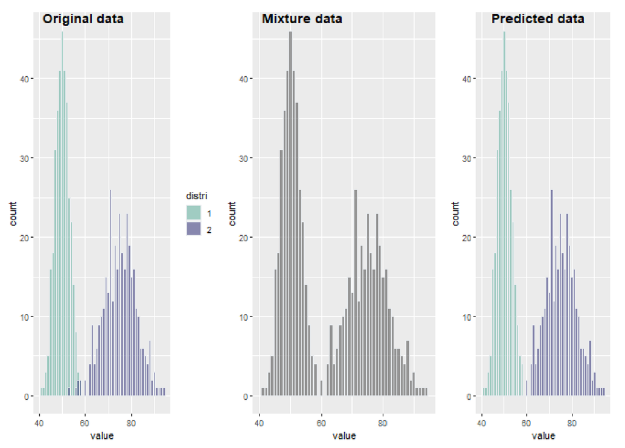

Figure 3.1: Two Gaussian distributions in 1D (with separable clusters). The figure on the LHS presents the two true Gaussian components. The figure in the middle represents the observed mixed data. The figure on the RHS predicted data by EM clustering. The original data does not contain many overlapped points, and the two components can be distinguished visually. In this case, the EM algorithm works well with parameter estimations and clustering of the two distribution components.

With stopping criteria : $|l(\boldsymbol{\theta^{(s+1)}})-l(\boldsymbol{\theta^{(s)}})|< 0.1$ , Em converges after 21 iterations with

| Parameter | p | $\mu_1$ | $\sigma_1$ | $\mu_2$ | $\sigma_2$ |
| --- | --- | --- | --- | --- | --- |
| True Value | 0.5 | 50 | 3 | 75 | 7 |
| Initial | 0.5 | 40 | 6.81 | 50 | 6.81 |
| Predicted | 0.504 | 50.1 | 3.12 | 75.1 | 6.89 |

Now, since the predicted probability of distribution 1 is 0.504, we can use this number as the threshold for distribution clustering. Comparing the predicted $\pi_i$ of each data point with $p=0.504$, the data point with $\p_i<p$ is predicted to be in distribution 1, otherwise it is in distribution 2. We have that the correct prediction rate is 694/700.

| err | n |
| --- | --- |
| 0 | 694 |
| 1 | 6 |

## 3.2 Example 2: Two Gaussian distributions in 1 D (with inseparable clusters)

This example uses a data set, as shown in the LHS Fig.(3.2)on the LHS, generated from a two-component Gaussian mixture distribution with sample size $n=700$ the true parameter $p_1=p_2=0.5; Y_1\sim N(50, 16); Y_2 \sim N(75, 9)$.

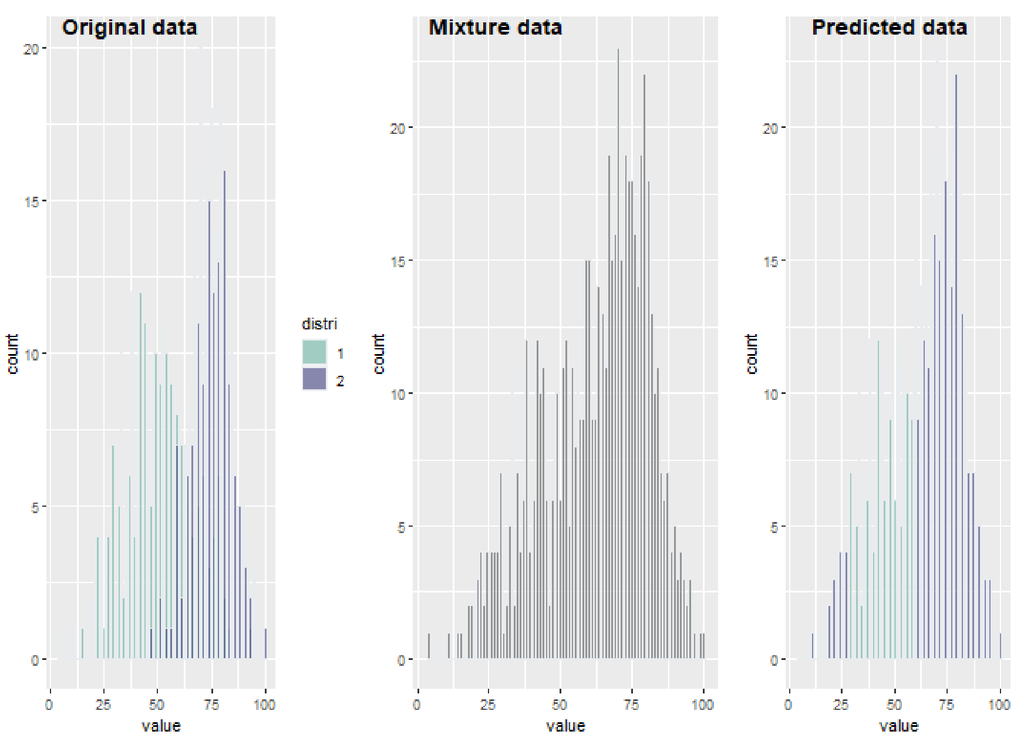

Figure 3.2: Two Gaussian distributions in 1 D (with inseparable clusters). The figure on the LHS presents the two true Gaussian components. The figure in the middle represents the observed mixed data. The figure on the RHS predicted data after clustering. The original data contains more overlapped points compared to Example 1. In this case, the EM algorithm works well with parameter estimations but the clustering result has a higher misclassification rate compared to Example 1.

With stopping criteria : $|l(\boldsymbol{\theta^{(s+1)}})-l(\boldsymbol{\theta^{(s)}})|< 0.1$ , Em converges after 362 iterations with

| Parameter | p | $\mu_1$ | $\sigma_1$ | $\mu_2$ | $\sigma_2$ |
| --- | --- | --- | --- | --- | --- |
| True Value | 0.5 | 50 | 16 | 75 | 9 |
| Initial | 0.5 | 25 | 5 | 75 | 12 |
| Predicted | 0.441 | 47.2 | 15 | 74.5 | 9.17 |

and correct clustering rate is $78.57\%$, the miss-classification rate is 21.43$\%$.

| err | n | percent |
| --- | --- | --- |
| -1 | 139 | 0.1985714 |
| 0 | 550 | 0.7857143 |
| 1 | 11 | 0.0157143 |

# 4 Appendix

Let’s $(X_1,X_2,\ldots X_n)$ IID random variables, $X_i \sim Bernoulli(p), \forall i \in \overline{1, n}$. We want to find $p$ that maximizes the likelihood.

- The likelihood is

$$\begin{align*}
L(p|X_1,\ldots, X_n) &= \prod_{i=1}^n f(X_i)=\prod_{i=1}^n p^{X_i} (1-p)^{(1-X_i)}=\\
&p^{\sum_i=1^n X_i} (1-p)^{(n-\sum_{i=1}^n X_i)}
\end{align*}$$

- The log-likelihood is

$$\begin{align*}
l(p|X_1,\ldots, X_n) &= \sum_{i=1}^n log(p^{X_i} (1-p)^{(1-X_i)})=\\
&= log(p) \sum_{i=1}^n (X_i) + log(1-p) (1- \sum_{i=1}^n (X_i) )\\
\end{align*}$$

# 5 Reference

McLachlan, G. J., & Krishnan, T. (2007). The EM algorithm and extensions (Vol. 382). John Wiley & Sons.

Ng, A. (2000). CS229 Lecture notes. CS229 Lecture notes, 1(1), 1-3.